# Introduction

1. Variables and Constants
2. Overflowing
3. Scope
4. Type Conversion
5. Operators
6. Comments

```csharp
using System;
// using System.Collections.Generic;
// using System.Linq;
// using System.Text;
// using System.Threading.Tasks;
```

```csharp
Console.WriteLine("Hello World");
```

```
Hello World
```

## Variables and Constants

Best to use Camel case, first letter small, and next word must be capital: firstName

Primitive Types (Most commonly used, there are others)

```
byte
short
int
long
float
double
decimal
char
bool
```

Lets look at real number. For real number, the double is default type for real number if it is not specified.

In order to specify it must be float, next to the number Same applies for decimail, which gets m suffix

```
float number = 1.2f
decimal dec = 1.7m
```

Then we have Non Primitive Types

```
String
Array
Enum
Class
```

We can also use `var`, then the compiler will decide for you.

## Overflowing

Eg. ehere byte data type largest value is 255, by adding 1, it will go back to 0.

But the below does not work...

But we need to stop overflowing, so we need to use the check keyword.

```csharp
int num = 2147483647;
num =  num + 1;
Console.Write(num); //gives an answer,but it is incorrect and overflows
```

```
-2147483648
```

```csharp
int num1;
checked
{
    num1 = 2147483647;
    num1 =  num1 + 1;
}
Console.Write(num1); //gives the error below, which is correct
```

[output not shown]

## Scope

A block is indicated by curly brackets, this defines a scope.

a and b, which is inside its own block, is inly visible inside their own block

But parents, such as a is visible inside child blocks.

```csharp
{
    int a = 1;
    {
        int b = 2;
        {
            int c = 3;
            Console.WriteLine(c);
            Console.WriteLine(a); //accessible
            Console.WriteLine(b); //accessible
        }
        Console.WriteLine(b);
    }
    Console.WriteLine(a);

    //Console.WriteLine(c); //outside scope. uncomment to see error

}
```

```
3
1
2
2
1
```

### Using Placeholders

Curly braces are used.

{0}, is the first variable found in string

{1}, is the second variable found in string

```csharp
byte numb = 2;
Console.WriteLine(numb);

Console.WriteLine("Byte -  min({0}) and max({1})", byte.MinValue, byte.MaxValue);
Console.WriteLine("Short - min({0}) and max({1})", short.MinValue, short.MaxValue);
Console.WriteLine("Int - min({0}) and max({1})", int.MinValue, int.MaxValue);
Console.WriteLine("Long - min({0}) and max({1})", long.MinValue, long.MaxValue);
Console.WriteLine("Float - min({0}) and max({1})", float.MinValue, float.MaxValue);
Console.WriteLine("Double - min({0}) and max({1})", double.MinValue, double.MaxValue);
Console.WriteLine("Decimal - min({0}) and max({1})", decimal.MinValue, decimal.MaxValue);
```

```
2
Byte -  min(0) and max(255)
Short - min(-32768) and max(32767)
Int - min(-2147483648) and max(2147483647)
Long - min(-9223372036854775808) and max(9223372036854775807)
Float - min(-3,4028235E+38) and max(3,4028235E+38)
Double - min(-1,7976931348623157E+308) and max(1,7976931348623157E+308)
Decimal - min(-79228162514264337593543950335) and max(79228162514264337593543950335)
```

## Type Conversion

### Implicit Type conversion

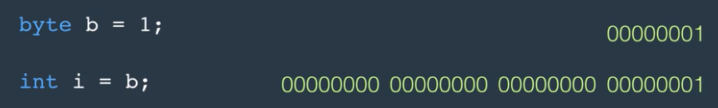

Or if we copy an int to a float, no data loss will occur as the types are compatible.

However implicity converting from large to small will produce an error,and implicit type conversion will not work

int to byte (see example below)

Here we need to explicity tell the compiler that we are aware of the data loss, but still want to go ahead with the conversion. This is also called casting

### Explicit Type conversion (casting)

So here we going from large to small, with the knowledge that there may be data loss, and the compiler wont cast it without our permission.

So we prefix the variable with the target type.

### Conversion between Non compatible types

Next we working with types that are not compatible, and we trying to do explicit conversion. This will not work as the types are not compatible.

Bur we still want "1" to be converted to a number. So how do we do it? Fot this type of situation we can use the following two ways:

1. Convert Class
2. Parse Class

E.g.

```
int j = Convert.ToInt32(s);
int j = int.Parse(s);
```

### Summary

1. Small to Large - implicit conversion, but types need to be compatible
2. Large to Small - implicit conversion will give error, need to do explicit conversion. Attach the tarhet data type to the variable
3. Converting between non combatible data type - implicit, and explicit conversion will not work. We have two options here: Convert or the Parse class.

```csharp
//Implicit Type conversion - all good - Types are compatible
byte nCon = 1;
int mCon = nCon;
Console.WriteLine(mCon);

//Implicit Type conversion - all good - Types are compatible
int inCon = 2;
float flCon=inCon;
Console.WriteLine(mCon);
```

```
1
1
```

```csharp
//Implicit Type conversion - large to small does not work
int inConv = 1;
byte mbCon = inConv;
Console.WriteLine(mbCon);
```

```
(3,14): error CS0266: Cannot implicitly convert type 'int' to 'byte'. An explicit conversion exists (are you missing a cast?)
```

Best approach here is not know that there will be data loss, and to know the max range of target data type.

```csharp
//Explicit Type conversion - large to small does not work
//Here we need to prefix the variable with the target type:

int inConv = 1;
byte mbCon = (byte)inConv;
Console.WriteLine(mbCon);
```

```
1
```

```csharp
//Explicit Type conversion - large to small does not work
//Here we need to prefix the variable with the target type:
(needs f suffix for float)

float fConv = 1.0f;
int i2Con = (int)fConv;
Console.WriteLine(i2Con);
```

```
(3,8): error CS1026: ) expected
(3,8): error CS1002: ; expected
(3,17): error CS1002: ; expected
(3,21): error CS1003: Syntax error, '(' expected
(3,21): error CS1525: Invalid expression term 'float'
(3,26): error CS1002: ; expected
(3,26): error CS1525: Invalid expression term ')'
(3,26): error CS1002: ; expected
```

```csharp
//Converting non compatible type, an
string sCon = "1";
int isCon = (int)sCon;
Console.WriteLine(isCon);
```

```
(3,13): error CS0030: Cannot convert type 'string' to 'int'
```

```csharp
//Converting non compatible type, using two following methods
string sCons = "1";
int is2Con = Convert.ToInt32(sCons);
int is3Con = int.Parse(sCons);
Console.WriteLine(is2Con);
Console.WriteLine(is3Con);
```

```
1
1
```

## Operators

We have 5 types of operators.

1. Arithmetic

+, -, / * , % (Remainder of division)

++, -- (shortcuts for adding 1 or subtracting 1)

#### Used as Postfix

```
int a = 1
in b = a++
```

1. First a is assigned to b
2. Then a is incremented by 1
3. B is NOT a + 1

```
int a = 1
in b = ++a
```

The pre and postix is applied to RHS variable

#### Used as Prefix

1. Comparison

==,!=, <, <=, >, >=

1. Assignment

=,+=, -=, *=, /=

```
a+=3, same as a=a+3, etc
```

1. Logical

&&, ||, !

Used in conditional statements

1. Bitwise

&, |

```csharp
//Postfix, b set to a, then a is incremented by 1
int aPost = 1;
int bPost = aPost++;
Console.WriteLine("a = {0}",aPost);
Console.WriteLine("b = {0}",bPost);
```

```
a = 2
b = 1
```

```csharp
//Prefix, a in incremented by 1, then a is assigned to b
int aPre = 1;
int bPre = ++aPre;
Console.WriteLine("a = {0}",aPre);
Console.WriteLine("b = {0}",bPre);
```

```
a = 2
b = 2
```

## Comments

Single line

//This is comment

Block

/* This is block comment

*/